SECU0005 Crime Mapping | 2026

# Lecture 2: Coordinate reference systems

## Today

- Continuous Module Dialogue
- Feedback from the Week 2 exercise
- Quiz
- Co-ordinate reference systems

# Feedback from the Week 2 exercise

## Minimal working answer

```r
# This script produces a dot map of thefts from vehicles in Vancouver in 2020

# Load packages
pacman::p_load(here, httr2, sf, sfhotspot, tidyverse)

# Download the original data and keep a local copy
request(
  "https://mpjashby.github.io/crimemappingdata/vancouver_thefts.csv.gz"
) |>
  req_perform(path = here("data", "raw", "vancouver_thefts.csv.gz")) |>
  # Stop `req_perform()` print a message to the console
  invisible()

# Read and wrangle data
thefts_from_vehicles <- here("data", "raw", "vancouver_thefts.csv.gz") |>
  read_csv() |>
  # Convert column names to snake-case
  janitor::clean_names() |>
  # Convert object to an object that understands each row represents a location
  # on the Earth's surface
  st_as_sf(coords = c("x", "y"), crs = "EPSG:32610") |>
  # Keep only the rows in the dataset relating to thefts from vehicles
  filter(type == "Theft from Vehicle")

# Create a dot map of thefts from vehicles
hotspot_map(
  thefts_from_vehicles,
  basemap_type = "cartodark",
  colour = "orange3",
  size = 0.75
)
```

## Minimal working answer

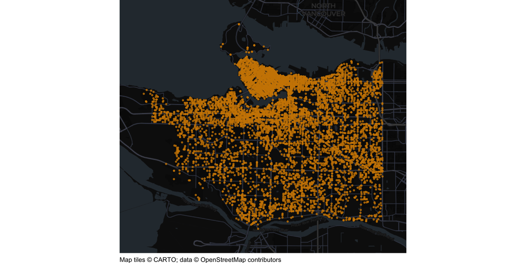

## ⚠️ Read the instructions

> For this week’s exercise, you must submit the R code needed to make a dot map of **thefts from vehicles** in Vancouver **in 2020**.

🚫 No other maps

🚫 No other crime categories

🚫 No data for other years

## ⚠️ Read the instructions

> You should submit only the R code, not an image of the map itself. Your code should be submitted in a single file that has the .R file extension.

🚫 No multiple `.R` files

🚫 No files without a file extension

🚫 No image files

🚫 No zip files

## 😠 Not acting on last week’s feedback

- Temporary code like `head()` or `learncrimemapping::check_code()` in script file
- Loading packages part-way through a script
- Lines over 80 characters long
- Not using blank lines to separate chunks of code
- Comments that don’t start with `#` *and a space*

## ⚠️ Don’t use `ggplot()` (yet) to make maps

```r
# Create an empty map canvas
ggplot() +
  # Add a pale background base map
  annotation_map_tile(type = "cartolight", zoomin = 0, progress = "none") +
  # Add small, transparent points so clusters show up darker
  geom_sf(
    data = thefts_vehicles_sf,
    colour = "#FF0000",
    alpha = 0.1
  ) +
  labs(
    caption = "Map tiles ©️ CARTO; data ©️ OpenStreetMap contributors"
  )
```

```r
hotspot_map(thefts_vehicles_sf, basemap_type = "cartolight", alpha = 0.1)
```

## The base map should not distract from the data

#### `basemap_type =`

#### `"opencycle"` 🚫

[figure not shown]

#### `"osm"` 🤔

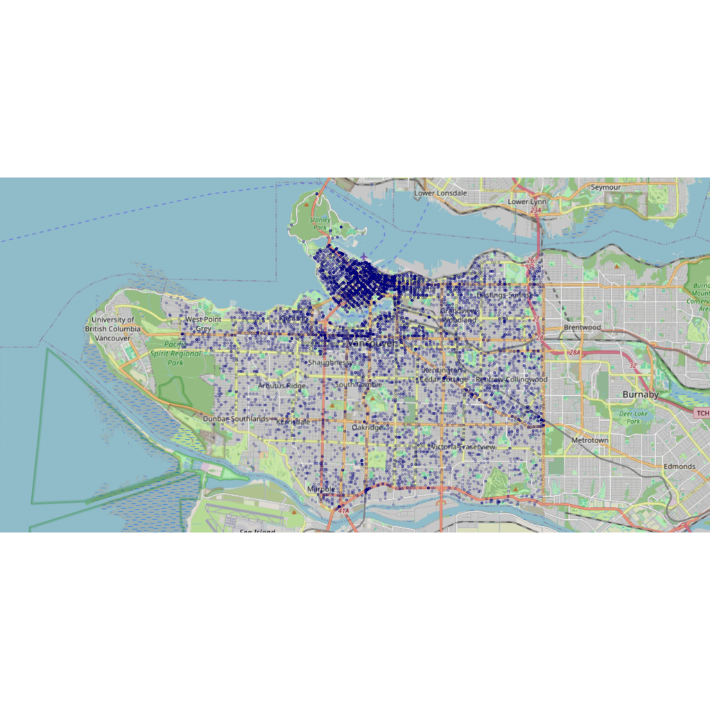

#### `"cartolight"` 😎

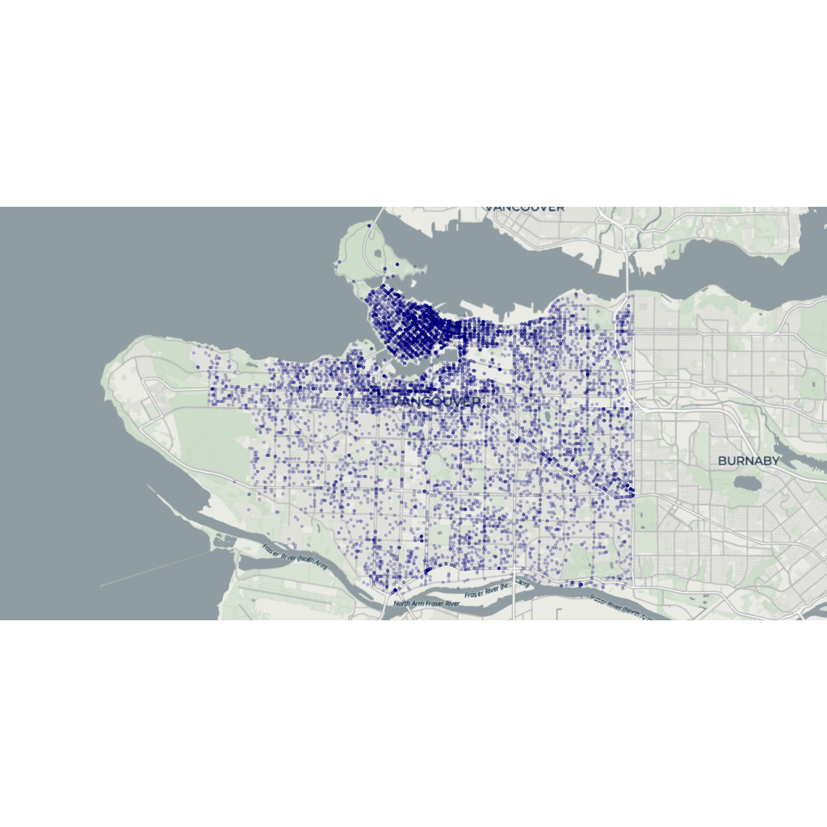

## ⚠️ Be careful with file names (`_` != `-`)

```r
# Download the theft data and saving it in local file
request(
  "https://mpjashby.github.io/crimemappingdata/vancouver_thefts.csv.gz"
) |>
  req_perform(path = here("data", "raw", "vancouver-thefts.csv.gz"))
```

```
<httr2_response>
GET https://mpjashby.github.io/crimemappingdata/vancouver_thefts.csv.gz
Status: 200 OK
Content-Type: application/gzip
Body: On disk '/Users/mattashby/Documents/Crime Mapping Book/lectures/2026/data/raw/vancouver-thefts.csv.gz' (422683 bytes)
```

```r
# Read the downloaded data and clean the column names
thefts <- read.csv(here("data", "raw", "vancouver_thefts.csv.gz")) |>
  janitor::clean_names()
```

## ⚠️ Be careful with file types (`.csv` != `.csv.gz`)

```r
# Download the theft data and saving it in local file
request(
  "https://mpjashby.github.io/crimemappingdata/vancouver_thefts.csv.gz"
) |>
  req_perform(path = here("data", "raw", "vancouver_thefts.csv"))
```

```
<httr2_response>
GET https://mpjashby.github.io/crimemappingdata/vancouver_thefts.csv.gz
Status: 200 OK
Content-Type: application/gzip
Body: On disk '/Users/mattashby/Documents/Crime Mapping Book/lectures/2026/data/raw/vancouver_thefts.csv' (422683 bytes)
```

```r
# Read the downloaded data and clean the column names
thefts <- read.csv(here("data", "raw", "vancouver_thefts.csv.gz")) |>
  janitor::clean_names()
```

## ⚠️ Be careful copying and pasting code from previous exercises

```r
# Create a basic crime map
hotspot_map(
  bike_thefts,
  basemap_type = "cartolight",
  colour = "red",
  size = 0.7,
  alpha = 0.1
)
```

[figure not shown]

# Co-ordinate reference systems

## Numbers on their own could mean anything

| x | y |
| --- | --- |
| −0.1228 | 51.5259 |

Location of this building

| x | y |
| --- | --- |
| 530,324 | 182,442 |

Also location of this building

| x | y |
| --- | --- |
| 174.2 | 86.8 |

Someone’s height and weight

## Co-ordinates are only meaningful if we know what they represent

numeric co-ordinates + co-ordinate reference system

e.g.

-0.1228, 51.5259 + EPSG:4326

or

530324, 182442 + EPSG:27700

## Co-ordinate reference systems specify …

… an origin point

e.g. in the British National Grid (EPSG:27700):

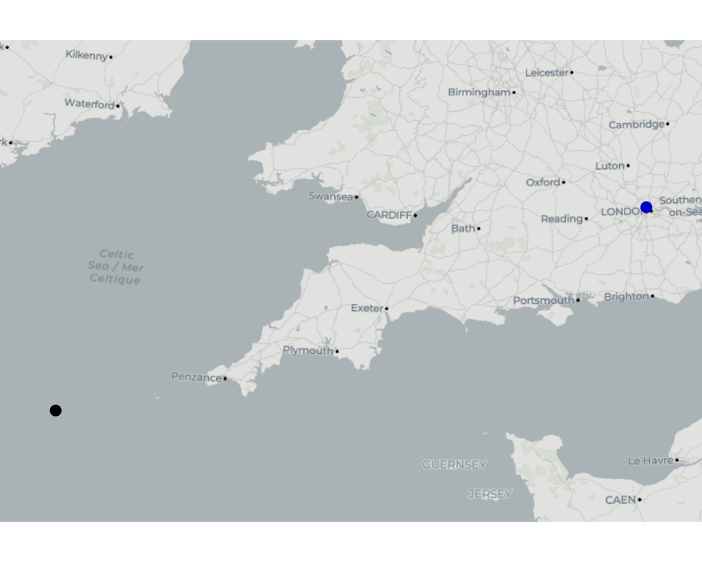

## Co-ordinate reference systems specify …

… an origin point

… a unit of measurement

e.g. in the British National Grid (EPSG:27700):

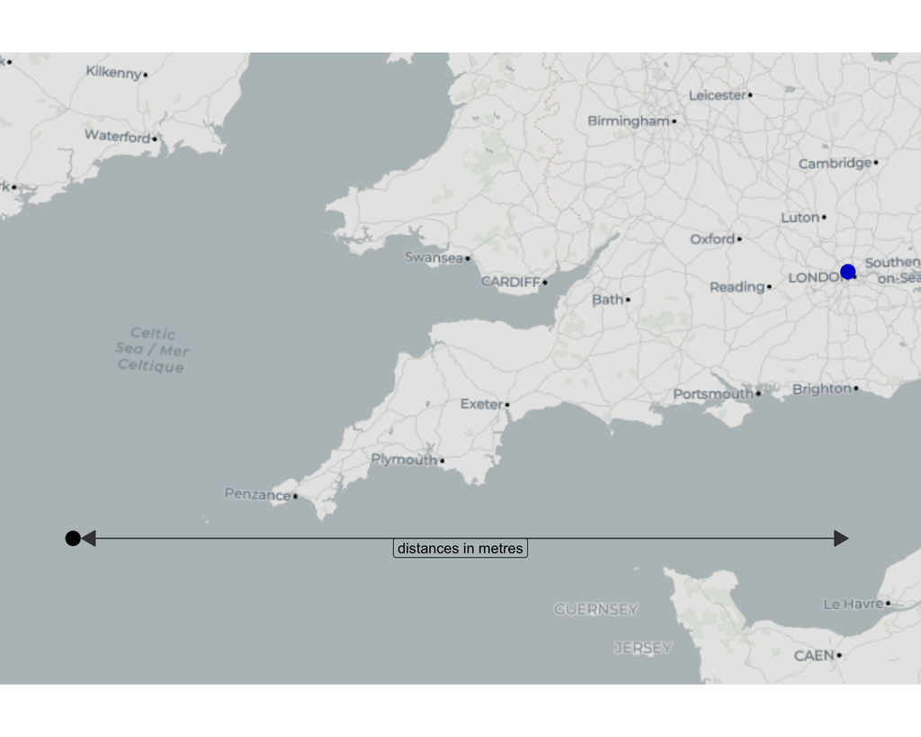

## Co-ordinate reference systems specify …

… an origin point

… a unit of measurement

… a system for representing a spherical earth on a flat map

e.g. in the British National Grid (EPSG:27700):

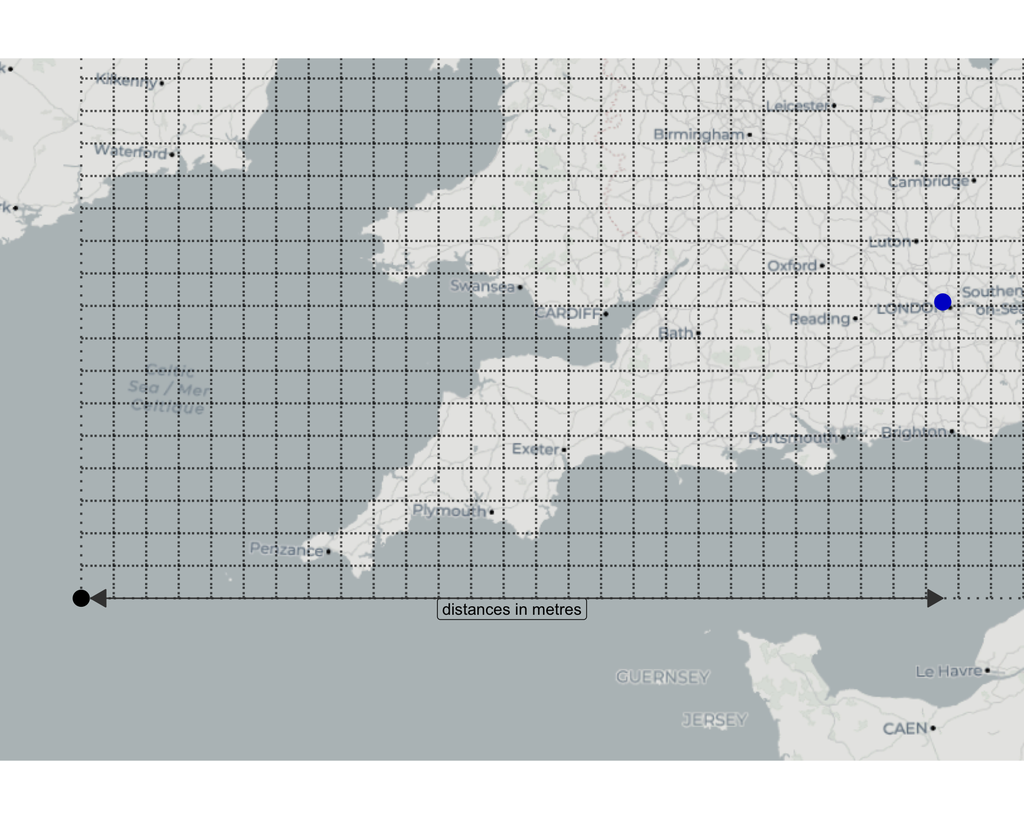

## But that (usually) only works for a part of the world

EPSG:27700 works for London, UK …

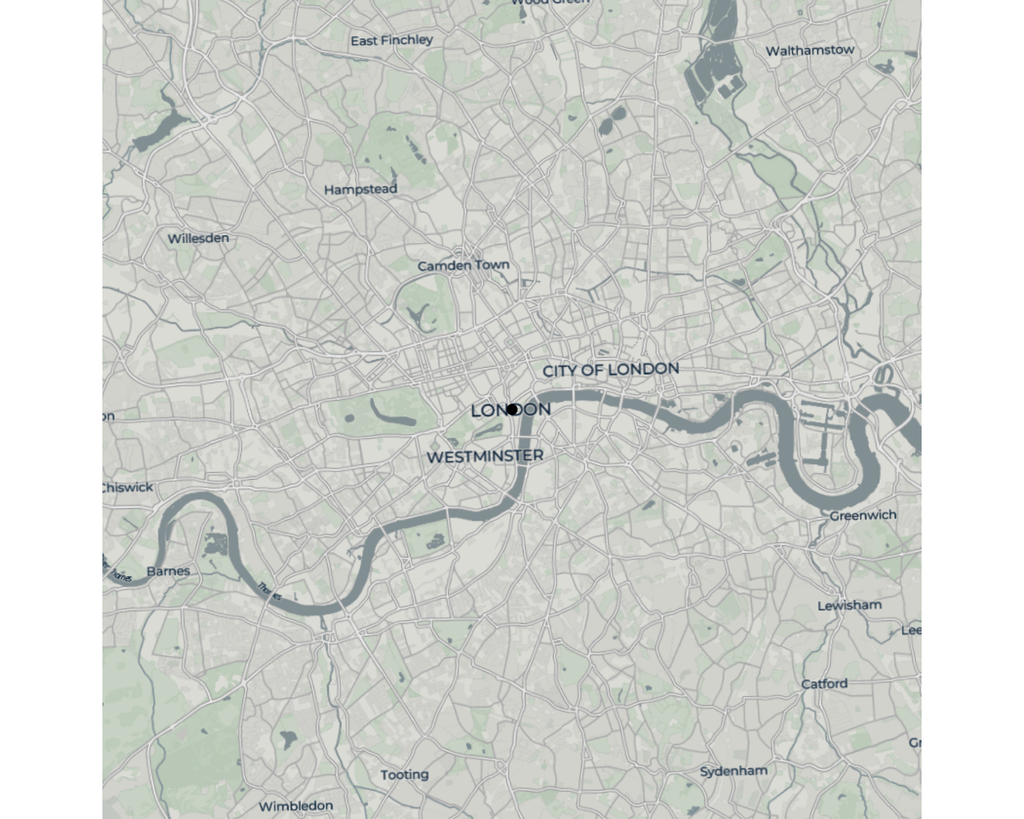

… but not for Sydney, Australia:

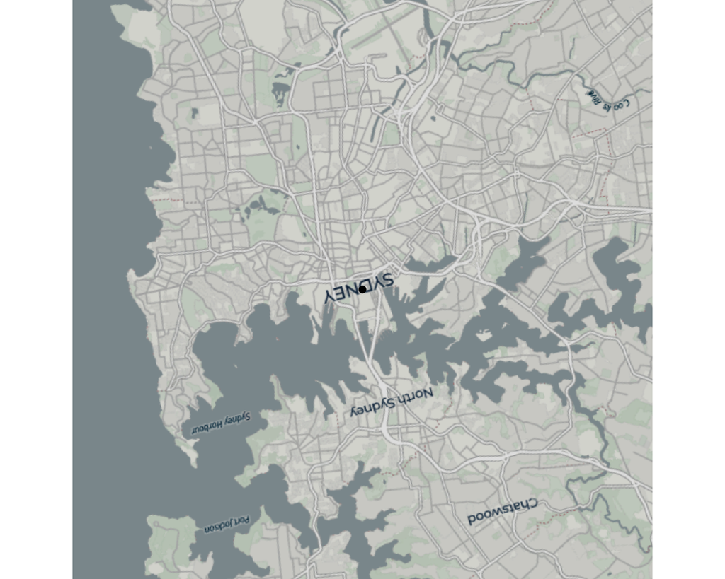

## An EPSG code represents an entry in a database of co-ordinate systems

For example …

| co-ordinate reference system | EPSG code | units | area covered |
| --- | --- | --- | --- |
| NAD83 / Georgia West | EPSG:26967 | metres | US state of Georgia |
| NAD83 / Georgia West (ftUS) | EPSG:2240 | feet | US state of Georgia |
| NAD83 / UTM zone 16N | EPSG:26916 | metres | Mid-west of North America |
| NAD83(2011) / New York Long Island | EPSG:6538 | metres | New York City |
| NAD83(NSRS2007) / Missouri West | EPSG:3603 | metres | US state of Missouri |
| OSGB36 / British National Grid | EPSG:27700 | metres | Great Britain |
| WGS 84 / UTM zone 10N | EPSG:32610 | metres | West coast of North America |
| WGS84 | EPSG:4326 | degrees | whole world |

EPSG:4326 can be used anywhere in the world

*but* degrees are a difficult unit to work with

## Co-ordinates only make sense with the *right* CRS

#### 😎 -0.1228, 51.5259 + “EPSG:4326”

```
Simple feature collection with 1 feature and 0 fields
Geometry type: POINT
Dimension:     XY
Bounding box:  xmin: -0.1227806 ymin: 51.52586 xmax: -0.1227806 ymax: 51.52586
Geodetic CRS:  WGS 84
# A tibble: 1 × 1
               geometry
            <POINT [°]>
1 (-0.1227806 51.52586)
```

co-ordinates make sense

#### 😲 -0.1228, 51.5259 + “EPSG:27700”

```
Simple feature collection with 1 feature and 0 fields
Geometry type: POINT
Dimension:     XY
Bounding box:  xmin: -0.1227806 ymin: 51.52586 xmax: -0.1227806 ymax: 51.52586
Projected CRS: OSGB36 / British National Grid
# A tibble: 1 × 1
               geometry
*           <POINT [m]>
1 (-0.1227806 51.52586)
```

no error message, but co-ordinates don’t make sense

## Which CRS should I use?

#### Spatial file formats

e.g. `.gpkg`, `.geojson`, `.shp`

**R will automatically extract CRS from data file**

#### Lat/long data

e.g. `.csv` with columns called `latitude`/`longitude` or similar

**Use EPSG:4326**

#### Other non-spatial file format

e.g. `.csv` with columns called `x`/`y`, etc.

**You *must* find out which CRS to use**

**Don’t guess**: it will be very hard to work out if you’re guess was correct or not

Ask whoever gave you the dataset

# Assessment 1

## Assessment 1

- In class on Tuesday 3 November (Week 5)
- 3 hours (+ extra time)
- You will produce 2 maps
- Open book
- Individual work, not groups

# This week

- 📖 complete chapters 6 and 7
- 💻 complete this week’s exercise
- 👋 ask questions at any time

[figure not shown]